# Homework 0 - Basic inference and GitHub submission

Chaewon Lee

08/21/2022

# Question 1

Given $X_i$ where $i = 1, ..., 10$, a random sample from a distribution with cdf

$$F(x) = 1 - e^{-a x}$$

for $x \ge 0$ and zero otherwise, derive and calculate for the given sample the maximum likelihood estimate (MLE) of $a$.

```r
set.seed(1)
a <- 5
x <- rexp(10, rate=a)
```

$$f(x) = ae^{-ax}$$

$$L(a | X_1, ..., X_{10}) =
f(X_1|a)*f(X_2|a)*...*f(X_{10}|a) \\ =
ae^{-aX_1}*ae^{-aX_2}...*ae^{-aX_{10}} \\ =
a^{10}e^{-a(X_1+X_2+...+X_10)}$$

We know that $\sum_{x = 1}^{10}x = 1.685244$
$$L(a | X_1, ..., X_{10})
= a^{10}e^{-1.685244a}$$

Here, we take the natural logarithm.
$$l(a | X_1, ..., X_{10}) = 10ln{(a)}-1.685244a$$
$$\displaystyle \frac{\partial l(a | X_1, ...,
X_{10})}{\partial a} = \frac{10}{a}-1.685244=0$$
Therefore, MLE of $a = 5.933857\approx 5.9$.

# Question 2

Suppose we have a bivariate distribution with

$$f(x, y) = x y^2 / 13$$

with support $\{(1,1), (1,2), (2,2)\}$. Compute $E(X|Y=2)$

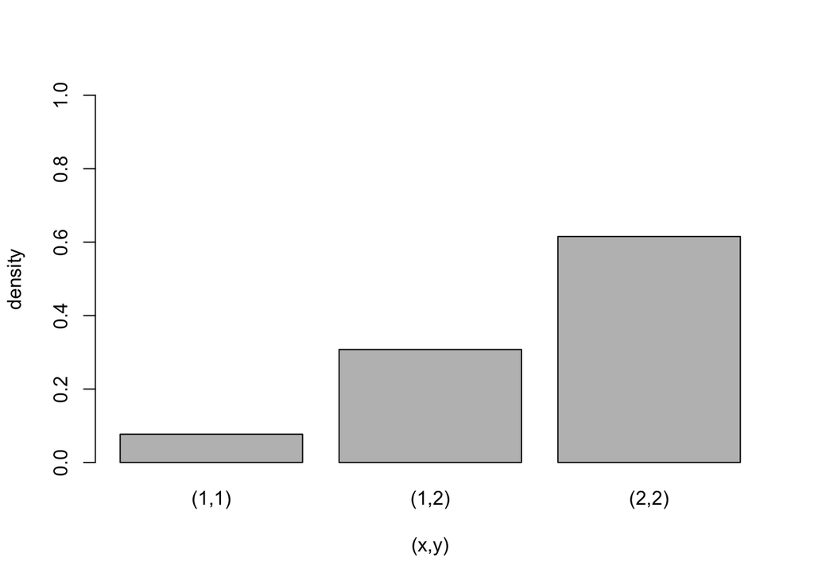

From the provided pdf of (x,y), we know that f(1,1) = $\frac{1}{13}$, f(1,2) = $\frac{4}{13}$, f(2,1) = 0, f(2,2) = $\frac{8}{13}$.
$$E(X|Y=2) = \sum_{X=x} x f(x|Y=2) \\ =
1*\frac{f(x=1,y=2)}{f_{y}(y=2)} + 2*\frac{f(x=2,y=2)}{f_{y}(y=2)} \\ =
1*\frac{4/13}{12/13} + 2*\frac{8/13}{12/13} \\ = 1* \frac{1}{3} +
2*\frac{2}{3} \\ = \frac{5}{3}$$

# Question 3

There are three coins in a bag, two are fair with $P(\textrm{heads}) = 0.5$ and one is biased with $P(\textrm{heads}) = 0.75$. Suppose we pull a coin out and flip it 4 times, getting heads 3 times. What is the posterior probability the coin was the biased one?

```r
coin <- c(1,1,0,1)
```

Let 𝑋 be the random variable that indicates the number of flips that revealed head.

Here, $\textrm{P({H,H,T,H})} = P(X = 3)$.

Coin A and Coin B are fair coins with $\textrm{P(H|A) = P(H|B) = 0.5}$, and Coin C is a biased coin with P(H|C) = 0.75.

What we want to know is $\textrm{P(C|{H,H,T,H})=P(C|X=3})$.

And we know that $\textrm{P(A)=P(B)=P(C)}=\frac{1}{3}$.

Since each flip is independent, and following the Bayes’ theorem,

$P(A,X=3)=P(X=3|A)*P(A)=P(H|A)*P(H|A)*P(T|A)*P(H|A)*P(A)=\frac{1}{3}*(0.5)^3*(0.5)$

As both coin A and B are fair coins, we can summarize as follows.